# Portfolio 1 — Experimental Methods 1 2019

Fabio Trecca

9/19/2019

```r
knitr::opts_chunk$set(echo = TRUE, include = TRUE)
pacman::p_load(tidyverse, ggplot2)
```

## Portfolio exam - Part 1

#### Write a short data mining report on the CogSci Intro Week Personality Test Data in which you answer the following questions in prose, code and graphs:

First of all, you have to import the personality data. If the dataset is in your working directory, then you can just load it into R. Otherwise you will have to change your working directory.

```r
df <- read.csv("data/NEW_CogSciPersonalityTest2019.csv", header = TRUE)
```

Once you are done loading the data, you can start working on the questions below.

#### Question 1

Who can hold their breath longer on average, those with right or left ocular dominance? Plot the data using ggplot2 to find out. The plots should include error bars (depicting the standard error of the means). Then use the mean() and sd() functions to find mean and standard deviation of the two eye dominance groups.

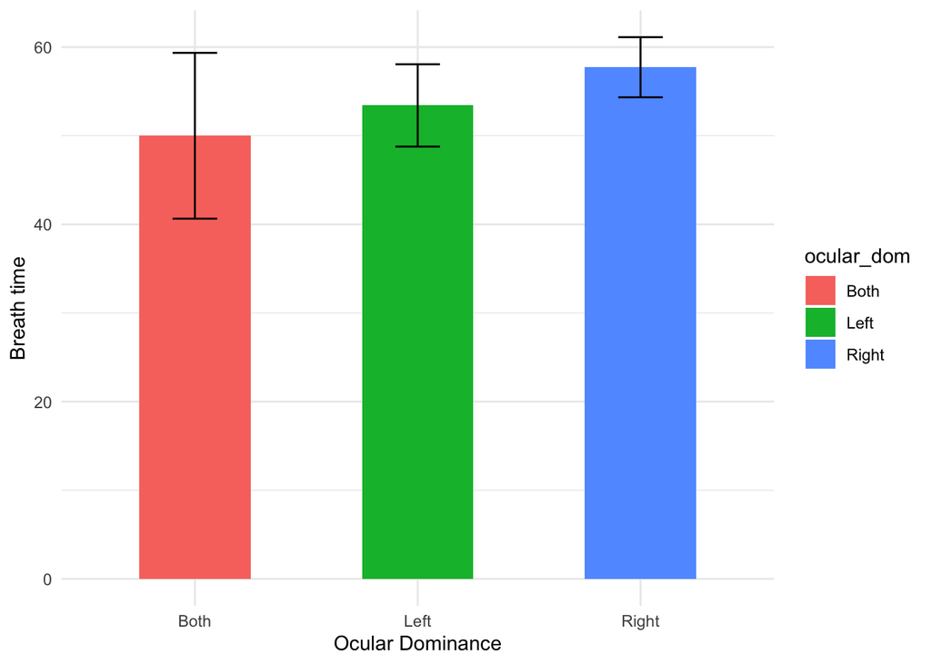

```r
ggplot(df, aes(x = ocular_dom, y = breath_hold, fill = ocular_dom)) +
  geom_bar(stat = 'summary', fun.y = mean, width = 0.5) +
  geom_errorbar(stat = 'summary', fun.data = mean_se, width = 0.2) +
  labs(x = "Ocular Dominance", y = "Breath time") +
  theme_minimal()
```

```r
df %>%
  group_by(ocular_dom) %>%
  summarise(mean(breath_hold),sd(breath_hold),n())
```

```
## # A tibble: 3 x 4
##   ocular_dom `mean(breath_hold)` `sd(breath_hold)` `n()`
##   <fct>                    <dbl>             <dbl> <int>
## 1 Both                      50                18.7     4
## 2 Left                      53.4              21.3    21
## 3 Right                     57.7              20.6    37
```

#### Question 2

Who likes silence vs. noise best? Males or females? Also in this case you should plot the data using ggplot2 (including error bars), then use the mean() and sd() functions to find mean and standard deviation of the two genders.

#### Question 3

Are the breath_hold data normally distributed? Provide visual and numeric support for your answer.

#### Question 4

Are the Balloon reaction time data (balloon and balloon_balance) normally distributed? Provide visual and numeric support for your answer.

#### Question 5

Shoe size could tell us something about general body size, which could also be connected to one’s ability to hold your breath. In other words we predict that there is a positive relation between shoe size and how long time CogSci students can hold their breath. Try plotting the two sets of data against each other using a scatter plot (hint: both variables are continuous variables). Bonus question: Males and females have different body sizes. Use grouping in your plot to distinguish the relationship between shoe size and holding breath for males and females.